# **Facial Emotion Detection**

## **Creating our Data Loaders**

In this section, we are creating data loaders that we will use as inputs to our Neural Network. A sample of the required code has been given with respect to the training data.

```python
# Prepare 'rbg' images for the CNN modeling (48, 48, 3)
batch_size  = 32
img_size = 48

datagen_train = ImageDataGenerator(horizontal_flip = True,
                                    brightness_range = (0., 2.),
                                    rescale = 1./255,
                                    shear_range = 0.3)

train_set = datagen_train.flow_from_directory(folder_path + "train/",
                                              target_size = (img_size, img_size),
                                              color_mode = 'rgb',
                                              batch_size = batch_size,
                                              class_mode = 'categorical',
                                              classes = ['happy', 'sad', 'neutral', 'surprise'],
                                              shuffle = True)

datagen_validation = ImageDataGenerator(rescale = 1./255)

validation_set = datagen_train.flow_from_directory(folder_path + "validation/",
                                              target_size = (img_size, img_size),
                                              color_mode = 'rgb',
                                              batch_size = batch_size,
                                              class_mode = 'categorical',
                                              classes = ['happy', 'sad', 'neutral', 'surprise'],
                                              shuffle = True)

datagen_test = ImageDataGenerator(rescale = 1./255)

test_set = datagen_train.flow_from_directory(folder_path + "test/",
                                              target_size = (img_size, img_size),
                                              color_mode = 'rgb',
                                              batch_size = batch_size,
                                              class_mode = 'categorical',
                                              classes = ['happy', 'sad', 'neutral', 'surprise'],
                                              shuffle = True)
```

```
Found 15109 images belonging to 4 classes.
Found 4977 images belonging to 4 classes.
Found 128 images belonging to 4 classes.
```

## **Model Building**

### **Creating the Base Neural Network**

Our Base Neural network will be a fairly simple model architecture.

- We want our Base Neural Network architecture to have 3 convolutional blocks.
- Each convolutional block must contain one Conv2D layer followed by a maxpooling layer and one Dropout layer. We can play around with the dropout ratio.
- First Conv2D layer with **64 filters** and a **kernel size of 2**. Use the 'same' padding and provide the **input_shape = (48, 48, 3) if you are using 'rgb' color mode in dataloader or else input shape = (48, 48, 1) if you're using 'grayscale' colormode**. Use **'relu' activation**.
- MaxPooling2D layer with **pool size = 2**.
- A Dropout layer with a dropout ratio of 0.2.
- A second Conv2D layer with **32 filters** and a **kernel size of 2**. Use the **'same' padding** and **'relu' activation.**
- Follow this up with a similar Maxpooling2D layer like above and a Dropout layer with 0.2 Dropout ratio to complete second Convolutional Block.
- A third Conv2D layer with **32 filters** and a **kernel size of 2**. Use the **'same' padding** and **'relu' activation.** Once again, follow it up with a Maxpooling2D layer and a Dropout layer to complete third Convolutional block.
- After adding convolutional blocks, add Flatten layer.
- Add first Dense layer with **512 neurons**. Use **'relu' activation function**.
- Add a Dropout layer with dropout ratio of 0.4.
- Add final Dense Layer with 4 neurons and **'softmax' activation function**
- Print model summary

```python
# Define model 1: CNN for RGB images

# Initializing a Sequential Model
model1 = Sequential()

# Add the first Convolutional block
model1.add(Conv2D(filters = 64, kernel_size = 2, padding = "same", input_shape = (48, 48, 3), activation = 'relu'))
model1.add(MaxPooling2D(pool_size = 2))
model1.add(Dropout(0.2))


# Add the second Convolutional block
model1.add(Conv2D(filters = 32, kernel_size = 2, padding = "same", input_shape = (48, 48, 3), activation = 'relu'))
model1.add(MaxPooling2D(pool_size = 2))
model1.add(Dropout(0.2))

# Add the third Convolutional block
model1.add(Conv2D(filters = 32, kernel_size = 2, padding = "same", input_shape = (48, 48, 3), activation = 'relu'))
model1.add(MaxPooling2D(pool_size = 2))
model1.add(Dropout(0.2))

# Add the Flatten layer
model1.add(Flatten())

# Add the first Dense layer
model1.add(Dense(512,activation = 'relu'))
model1.add(Dropout(0.4))

# Add the Final layer
model1.add(Dense(4,activation = 'softmax'))

model1.summary()
```

```
Model: "sequential"
_________________________________________________________________
 Layer (type)                Output Shape              Param #
=================================================================
 conv2d (Conv2D)             (None, 48, 48, 64)        832

 max_pooling2d (MaxPooling2  (None, 24, 24, 64)        0
 D)

 dropout (Dropout)           (None, 24, 24, 64)        0

 conv2d_1 (Conv2D)           (None, 24, 24, 32)        8224

 max_pooling2d_1 (MaxPoolin  (None, 12, 12, 32)        0
 g2D)

 dropout_1 (Dropout)         (None, 12, 12, 32)        0

 conv2d_2 (Conv2D)           (None, 12, 12, 32)        4128

 max_pooling2d_2 (MaxPoolin  (None, 6, 6, 32)          0
 g2D)

 dropout_2 (Dropout)         (None, 6, 6, 32)          0

 flatten (Flatten)           (None, 1152)              0

 dense (Dense)               (None, 512)               590336

 dropout_3 (Dropout)         (None, 512)               0

 dense_1 (Dense)             (None, 4)                 2052

=================================================================
Total params: 605572 (2.31 MB)
Trainable params: 605572 (2.31 MB)
Non-trainable params: 0 (0.00 Byte)
_________________________________________________________________
```

### **Compiling and Training the Model**

```python
from keras.callbacks import ModelCheckpoint, EarlyStopping, ReduceLROnPlateau

checkpoint = ModelCheckpoint("./model1.h5", monitor='val_acc', verbose=1, save_best_only=True, mode='max')

early_stopping = EarlyStopping(monitor = 'val_loss',
                          min_delta = 0,
                          patience = 3,
                          verbose = 1,
                          restore_best_weights = True
                          )

reduce_learningrate = ReduceLROnPlateau(monitor = 'val_loss',
                              factor = 0.2,
                              patience = 3,
                              verbose = 1,
                              min_delta = 0.0001)

callbacks_list = [early_stopping, checkpoint, reduce_learningrate]

epochs = 20
```

```python
# Code to compile  model1. Use categorical crossentropy as  loss function, Adam Optimizer with 0.001 learning rate, and set  metrics to 'accuracy'.
model1.compile(optimizer=tf.keras.optimizers.Adam(learning_rate=0.001),loss='categorical_crossentropy', metrics=['accuracy'])
```

```python
# Code to fit  model1. Use train_set as  training data and validation_set as  validation data. Train  model for 20 epochs.

history_model1 = model1.fit(train_set, epochs=20, validation_data=validation_set, verbose=1)
```

### **Evaluating the Model on the Test Set**

```python
# Code to evaluate  model on test data.
test_images, test_labels = next(test_set)
accuracy = model1.evaluate(test_images, test_labels, verbose = 2)
```

```
1/1 - 0s - loss: 0.7040 - accuracy: 0.6875 - 26ms/epoch - 26ms/step
```

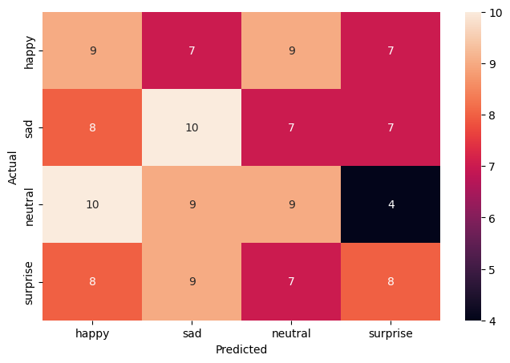

```python
from sklearn.metrics import classification_report
from sklearn.metrics import confusion_matrix

pred1 = model1.predict(test_set, steps=len(test_set))
pred1_labels = np.argmax(pred1, axis=1)
y_true1 = test_set.classes

# Plotting the heatmap using confusion matrix
cm1 = confusion_matrix(y_true1, pred1_labels)
plt.figure(figsize = (8, 5))
sns.heatmap(cm1, annot = True,  fmt = '.0f', xticklabels = ['happy', 'sad', 'neutral', 'surprise'], yticklabels = ['happy', 'sad', 'neutral', 'surprise'])
plt.ylabel('Actual')
plt.xlabel('Predicted')
plt.show()
```

```python
report = classification_report(y_true1, pred1_labels)
print(report)
```

```
              precision    recall  f1-score   support

           0       0.26      0.28      0.27        32
           1       0.29      0.31      0.30        32
           2       0.28      0.28      0.28        32
           3       0.31      0.25      0.28        32

    accuracy                           0.28       128
   macro avg       0.28      0.28      0.28       128
weighted avg       0.28      0.28      0.28       128
```

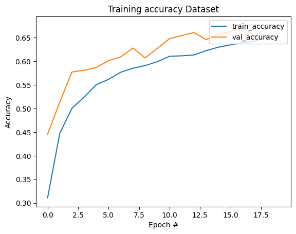

```python
def plot_history(history):
    N = len(history.history["accuracy"])
    plt.figure()
    plt.plot(np.arange(0, N), history.history["accuracy"], label="train_accuracy")
    plt.plot(np.arange(0, N), history.history["val_accuracy"], label="val_accuracy")
    plt.title("Training accuracy Dataset")
    plt.xlabel("Epoch #")
    plt.ylabel("Accuracy")
    plt.legend(loc="upper right")
plot_history(history_model1)
```

**Observations**

- The model did not overfit, but there seems to be some noise in the validation accuracy.
- The accuracies are generally low

```python
# Clearing backend

from tensorflow.keras import backend

backend.clear_session()

# Fixing the seed for random number generators

np.random.seed(42)

import random

random.seed(42)

tf.random.set_seed(42)
```

### **Creating a model that has the same layers but for 'grayscale' images**

```python
# Prepare 'grayscale' images for the CNN modeling (48, 48, 1)

batch_size  = 32
img_size = 48

datagen_train = ImageDataGenerator(horizontal_flip = True,
                                    brightness_range = (0., 2.),
                                    rescale = 1./255,
                                    shear_range = 0.3)

train_set_gray = datagen_train.flow_from_directory(folder_path + "train/",
                                              target_size = (48, 48),
                                              color_mode = 'grayscale',
                                              batch_size = batch_size,
                                              class_mode = 'categorical',
                                              classes = ['happy', 'sad', 'neutral', 'surprise'],
                                              shuffle = True)

datagen_validation = ImageDataGenerator(rescale = 1./255)

validation_set_gray = datagen_train.flow_from_directory(folder_path + "validation/",
                                              target_size = (48, 48),
                                              color_mode = 'grayscale',
                                              batch_size = batch_size,
                                              class_mode = 'categorical',
                                              classes = ['happy', 'sad', 'neutral', 'surprise'],
                                              shuffle = True)

datagen_test = ImageDataGenerator(rescale = 1./255)

test_set_gray = datagen_train.flow_from_directory(folder_path + "test/",
                                              target_size = (48, 48),
                                              color_mode = 'grayscale',
                                              batch_size = batch_size,
                                              class_mode = 'categorical',
                                              classes = ['happy', 'sad', 'neutral', 'surprise'],
                                              shuffle = True)
```

```
Found 15109 images belonging to 4 classes.
Found 4977 images belonging to 4 classes.
Found 128 images belonging to 4 classes.
```

```python
# Define the model1 for grayscale

# Initializing a Sequential Model
model1_gray = Sequential()

# Add the first Convolutional block
model1_gray.add(Conv2D(filters = 64, kernel_size = 2, padding = "same", input_shape = (48, 48, 1), activation = 'relu'))
model1_gray.add(MaxPooling2D(pool_size = 2))
model1_gray.add(Dropout(0.2))


# Add the second Convolutional block
model1_gray.add(Conv2D(filters = 32, kernel_size = 2, padding = "same", input_shape = (48, 48, 1), activation = 'relu'))
model1_gray.add(MaxPooling2D(pool_size = 2))
model1_gray.add(Dropout(0.2))

# Add the third Convolutional block
model1_gray.add(Conv2D(filters = 32, kernel_size = 2, padding = "same", input_shape = (48, 48, 1), activation = 'relu'))
model1_gray.add(MaxPooling2D(pool_size = 2))
model1_gray.add(Dropout(0.2))

# Add the Flatten layer
model1_gray.add(Flatten())

# Add the first Dense layer
model1_gray.add(Dense(512,activation = 'relu'))
model1_gray.add(Dropout(0.4))

# Add the Final layer
model1_gray.add(Dense(4,activation = 'softmax'))

model1_gray.summary()
```

```
Model: "sequential"
_________________________________________________________________
 Layer (type)                Output Shape              Param #
=================================================================
 conv2d (Conv2D)             (None, 48, 48, 64)        320

 max_pooling2d (MaxPooling2  (None, 24, 24, 64)        0
 D)

 dropout (Dropout)           (None, 24, 24, 64)        0

 conv2d_1 (Conv2D)           (None, 24, 24, 32)        8224

 max_pooling2d_1 (MaxPoolin  (None, 12, 12, 32)        0
 g2D)

 dropout_1 (Dropout)         (None, 12, 12, 32)        0

 conv2d_2 (Conv2D)           (None, 12, 12, 32)        4128

 max_pooling2d_2 (MaxPoolin  (None, 6, 6, 32)          0
 g2D)

 dropout_2 (Dropout)         (None, 6, 6, 32)          0

 flatten (Flatten)           (None, 1152)              0

 dense (Dense)               (None, 512)               590336

 dropout_3 (Dropout)         (None, 512)               0

 dense_1 (Dense)             (None, 4)                 2052

=================================================================
Total params: 605060 (2.31 MB)
Trainable params: 605060 (2.31 MB)
Non-trainable params: 0 (0.00 Byte)
_________________________________________________________________
```

```python
from keras.callbacks import ModelCheckpoint, EarlyStopping, ReduceLROnPlateau

checkpoint = ModelCheckpoint("./model1.h5", monitor='val_acc', verbose=1, save_best_only=True, mode='max')

early_stopping = EarlyStopping(monitor = 'val_loss',
                          min_delta = 0,
                          patience = 3,
                          verbose = 1,
                          restore_best_weights = True
                          )

reduce_learningrate = ReduceLROnPlateau(monitor = 'val_loss',
                              factor = 0.2,
                              patience = 3,
                              verbose = 1,
                              min_delta = 0.0001)

callbacks_list = [early_stopping, checkpoint, reduce_learningrate]

epochs = 20
```

```python
#compiling with grayscale
# Code to compile  model1. Use categorical crossentropy as loss function, Adam Optimizer with 0.001 learning rate, and set metrics to 'accuracy'.
model1_gray.compile(optimizer=tf.keras.optimizers.Adam(learning_rate=0.001),loss='categorical_crossentropy', metrics=['accuracy'])
```

```python
#Fitting with grayscale
# Code to fit  model1. Use train_set as  training data and validation_set as  validation data. Train  model for 20 epochs.

history_model1_gray = model1_gray.fit(train_set_gray, epochs=20, validation_data=validation_set_gray, verbose=1)
```

```python
test_images_gray, test_labels_gray = next(test_set_gray)
accuracy_gray = model1_gray.evaluate(test_images_gray, test_labels_gray, verbose = 2)
```

```
1/1 - 0s - loss: 0.7633 - accuracy: 0.7188 - 24ms/epoch - 24ms/step
```

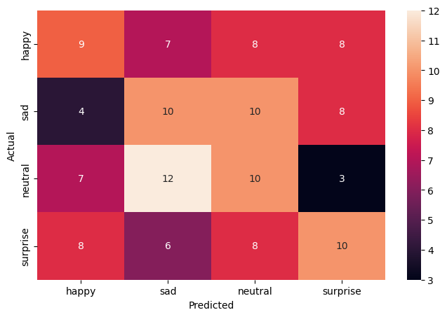

```python
from sklearn.metrics import classification_report
from sklearn.metrics import confusion_matrix

pred1_gray = model1_gray.predict(test_set_gray, steps=len(test_set_gray))
pred1_gray_labels = np.argmax(pred1_gray, axis=1)
y_true1_gray = test_set_gray.classes

# Plotting the heatmap using confusion matrix
cm1_gray = confusion_matrix(y_true1_gray, pred1_gray_labels)
plt.figure(figsize = (8, 5))
sns.heatmap(cm1_gray, annot = True,  fmt = '.0f', xticklabels = ['happy', 'sad', 'neutral', 'surprise'], yticklabels = ['happy', 'sad', 'neutral', 'surprise'])
plt.ylabel('Actual')
plt.xlabel('Predicted')
plt.show()
```

```python
report1_gray = classification_report(y_true1_gray, pred1_gray_labels)
print(report1_gray)
```

```
              precision    recall  f1-score   support

           0       0.32      0.28      0.30        32
           1       0.29      0.31      0.30        32
           2       0.28      0.31      0.29        32
           3       0.34      0.31      0.33        32

    accuracy                           0.30       128
   macro avg       0.31      0.30      0.31       128
weighted avg       0.31      0.30      0.31       128
```

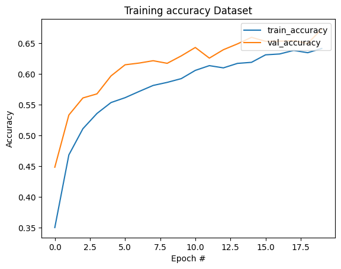

```python
def plot_history(history):
    N = len(history.history["accuracy"])
    plt.figure()
    plt.plot(np.arange(0, N), history.history["accuracy"], label="train_accuracy")
    plt.plot(np.arange(0, N), history.history["val_accuracy"], label="val_accuracy")
    plt.title("Training accuracy Dataset")
    plt.xlabel("Epoch #")
    plt.ylabel("Accuracy")
    plt.legend(loc="upper right")
plot_history(history_model1_gray)
```

```python
# Clearing backend
from tensorflow.keras import backend
backend.clear_session()

# Fixing the seed for random number generators
np.random.seed(42)
import random
random.seed(42)
tf.random.set_seed(42)
```

### **Observations**

- There isn't too big of a change from the first model.

### **Creating the second Convolutional Neural Network**

In the second Neural network, we will add a few more Convolutional blocks. We will also use Batch Normalization layers.

- This time, each Convolutional block will have 1 Conv2D layer, followed by a BatchNormalization, LeakuRelU, and a MaxPooling2D layer. We are not adding any Dropout layer this time.
- First Conv2D layer with **256 filters** and a **kernel size of 2**. Use the 'same' padding and provide the **input_shape = (48, 48, 3) if you are using 'rgb' color mode in dataloader or else input shape = (48, 48, 1) if you're using 'grayscale' colormode**. Use **'relu' activation**.
- BatchNormalization layer followed by a LeakyRelU layer with Leaky ReLU parameter of **0.1**
- MaxPooling2D layer with **pool size = 2**.
- Second Conv2D layer with **128 filters** and a **kernel size of 2**. Use the **'same' padding** and **'relu' activation.**
- Follow this up with a similar BatchNormalization, LeakyRelU, and Maxpooling2D layer like above to complete second Convolutional Block.
- Third Conv2D layer with **64 filters** and a **kernel size of 2**. Use the **'same' padding** and **'relu' activation.** Once again, follow it up with a BatchNormalization, LeakyRelU, and Maxpooling2D layer to complete third Convolutional block.
- Fourth block, with the Conv2D layer having **32 filters**.
- After adding convolutional blocks, add Flatten layer.
- First Dense layer with **512 neurons**. Use **'relu' activation function**.
- Second Dense Layer with **128 neurons** and use **'relu' activation** function.
- Final Dense Layer with 4 neurons and **'softmax' activation function**
- Print model summary

```python
#model 2 RGB
# Creating sequential model
model2 = Sequential()

# Add the first Convolutional block
model2.add(Conv2D(filters = 256, kernel_size = 2, padding = "same", input_shape = (48, 48, 3), activation = 'relu'))
model2.add(BatchNormalization())
model2.add(LeakyReLU(0.1))
model2.add(MaxPooling2D(pool_size = 2))

# Add the second Convolutional block
model2.add(Conv2D(filters = 128, kernel_size = 2, padding = "same", input_shape = (48, 48, 3), activation = 'relu'))
model2.add(BatchNormalization())
model2.add(LeakyReLU(0.1))
model2.add(MaxPooling2D(pool_size = 2))

# Add the third Convolutional block
model2.add(Conv2D(filters = 64, kernel_size = 2, padding = "same", input_shape = (48, 48, 3), activation = 'relu'))
model2.add(BatchNormalization())
model2.add(LeakyReLU(0.1))
model2.add(MaxPooling2D(pool_size = 2))

# Add the fourth Convolutional block
model2.add(Conv2D(filters = 32, kernel_size = 2, padding = "same", input_shape = (48, 48, 3), activation = 'relu'))

# Add the Flatten layer
model2.add(Flatten())

# Adding the Dense layers
model2.add(Dense(512, activation = 'relu'))
model2.add(Dense(128, activation = 'relu'))
model2.add(Dense(4, activation = 'softmax'))


model2.summary()
```

```
Model: "sequential"
_________________________________________________________________
 Layer (type)                Output Shape              Param #
=================================================================
 conv2d (Conv2D)             (None, 48, 48, 256)       3328

 batch_normalization (Batch  (None, 48, 48, 256)       1024
 Normalization)

 leaky_re_lu (LeakyReLU)     (None, 48, 48, 256)       0

 max_pooling2d (MaxPooling2  (None, 24, 24, 256)       0
 D)

 conv2d_1 (Conv2D)           (None, 24, 24, 128)       131200

 batch_normalization_1 (Bat  (None, 24, 24, 128)       512
 chNormalization)

 leaky_re_lu_1 (LeakyReLU)   (None, 24, 24, 128)       0

 max_pooling2d_1 (MaxPoolin  (None, 12, 12, 128)       0
 g2D)

 conv2d_2 (Conv2D)           (None, 12, 12, 64)        32832

 batch_normalization_2 (Bat  (None, 12, 12, 64)        256
 chNormalization)

 leaky_re_lu_2 (LeakyReLU)   (None, 12, 12, 64)        0

 max_pooling2d_2 (MaxPoolin  (None, 6, 6, 64)          0
 g2D)

 conv2d_3 (Conv2D)           (None, 6, 6, 32)          8224

 flatten (Flatten)           (None, 1152)              0

 dense (Dense)               (None, 512)               590336

 dense_1 (Dense)             (None, 128)               65664

 dense_2 (Dense)             (None, 4)                 516

=================================================================
Total params: 833892 (3.18 MB)
Trainable params: 832996 (3.18 MB)
Non-trainable params: 896 (3.50 KB)
_________________________________________________________________
```

### **Compiling and Training the Model**

```python
from keras.callbacks import ModelCheckpoint, EarlyStopping, ReduceLROnPlateau

checkpoint = ModelCheckpoint("./model1.h5", monitor='val_loss', verbose=1, save_best_only=True, mode='max')

early_stopping = EarlyStopping(monitor = 'val_loss',
                          min_delta = 0,
                          patience = 3,
                          verbose = 1,
                          restore_best_weights = True
                          )

reduce_learningrate = ReduceLROnPlateau(monitor = 'val_loss',
                              factor = 0.2,
                              patience = 3,
                              verbose = 1,
                              min_delta = 0.0001)

callbacks_list = [early_stopping, checkpoint, reduce_learningrate]

epochs = 20
```

```python
# Code to compile  model2. Use categorical crossentropy as the loss function, Adam Optimizer with 0.001 learning rate, and set metrics as 'accuracy'.

model2.compile(optimizer=tf.keras.optimizers.Adam(learning_rate=0.001),loss='categorical_crossentropy', metrics=['accuracy'])
```

```python
# Code to fit  model2. Use train_set as the training data and validation_set as the validation data. Train model for 20 epochs.
history_model2 = model2.fit(train_set, epochs=20, validation_data=validation_set, verbose=1)
```

### **Evaluating the Model on the Test Set**

```python
# Code to evaluate model's test performance

test_images, test_labels = next(test_set)
accuracy2 = model2.evaluate(test_images, test_labels, verbose = 2)
```

```
1/1 - 0s - loss: 0.9913 - accuracy: 0.6250 - 26ms/epoch - 26ms/step
```

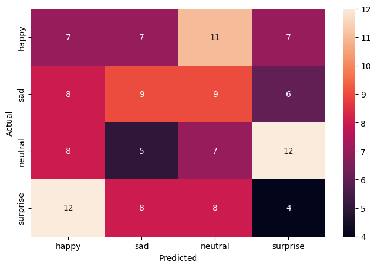

```python
from sklearn.metrics import classification_report
from sklearn.metrics import confusion_matrix

pred2 = model2.predict(test_set, steps=len(test_set))
pred2_labels = np.argmax(pred2, axis=1)
y_true2= test_set.classes

# Plotting the heatmap using confusion matrix
cm2 = confusion_matrix(y_true2, pred2_labels)
plt.figure(figsize = (8, 5))
sns.heatmap(cm2, annot = True,  fmt = '.0f', xticklabels = ['happy', 'sad', 'neutral', 'surprise'], yticklabels = ['happy', 'sad', 'neutral', 'surprise'])
plt.ylabel('Actual')
plt.xlabel('Predicted')
plt.show()
```

```python
report2 = classification_report(y_true2, pred2_labels)
print(report2)
```

```
              precision    recall  f1-score   support

           0       0.20      0.22      0.21        32
           1       0.31      0.28      0.30        32
           2       0.20      0.22      0.21        32
           3       0.14      0.12      0.13        32

    accuracy                           0.21       128
   macro avg       0.21      0.21      0.21       128
weighted avg       0.21      0.21      0.21       128
```

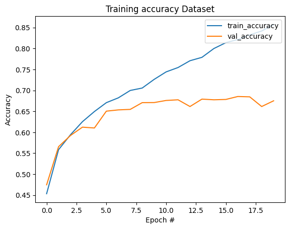

```python
def plot_history(history):
    N = len(history.history["accuracy"])
    plt.figure()
    plt.plot(np.arange(0, N), history.history["accuracy"], label="train_accuracy")
    plt.plot(np.arange(0, N), history.history["val_accuracy"], label="val_accuracy")
    plt.title("Training accuracy Dataset")
    plt.xlabel("Epoch #")
    plt.ylabel("Accuracy")
    plt.legend(loc="upper right")
plot_history(history_model2)
```

```python
# Clearing backend
from tensorflow.keras import backend
backend.clear_session()

# Fixing the seed for random number generators
np.random.seed(42)
import random
random.seed(42)
tf.random.set_seed(42)
```

### **Creating a second model for grayscale**

```python
#model 2 for Grayscale
# Creating sequential model
model2_gray = Sequential()

# Add the first Convolutional block
model2_gray.add(Conv2D(filters = 256, kernel_size = 2, padding = "same", input_shape = (48, 48, 1), activation = 'relu'))
model2_gray.add(BatchNormalization())
model2_gray.add(LeakyReLU(0.1))
model2_gray.add(MaxPooling2D(pool_size = 2))

# Add the second Convolutional block
model2_gray.add(Conv2D(filters = 128, kernel_size = 2, padding = "same", input_shape = (48, 48, 1), activation = 'relu'))
model2_gray.add(BatchNormalization())
model2_gray.add(LeakyReLU(0.1))
model2_gray.add(MaxPooling2D(pool_size = 2))

# Add the third Convolutional block
model2_gray.add(Conv2D(filters = 64, kernel_size = 2, padding = "same", input_shape = (48, 48, 1), activation = 'relu'))
model2_gray.add(BatchNormalization())
model2_gray.add(LeakyReLU(0.1))
model2_gray.add(MaxPooling2D(pool_size = 2))

# Add the fourth Convolutional block
model2_gray.add(Conv2D(filters = 32, kernel_size = 2, padding = "same", input_shape = (48, 48, 1), activation = 'relu'))

# Add the Flatten layer
model2_gray.add(Flatten())

# Adding the Dense layers
model2_gray.add(Dense(512, activation = 'relu'))
model2_gray.add(Dense(128, activation = 'relu'))
model2_gray.add(Dense(4, activation = 'softmax'))


model2_gray.summary()
```

```
Model: "sequential"
_________________________________________________________________
 Layer (type)                Output Shape              Param #
=================================================================
 conv2d (Conv2D)             (None, 48, 48, 256)       1280

 batch_normalization (Batch  (None, 48, 48, 256)       1024
 Normalization)

 leaky_re_lu (LeakyReLU)     (None, 48, 48, 256)       0

 max_pooling2d (MaxPooling2  (None, 24, 24, 256)       0
 D)

 conv2d_1 (Conv2D)           (None, 24, 24, 128)       131200

 batch_normalization_1 (Bat  (None, 24, 24, 128)       512
 chNormalization)

 leaky_re_lu_1 (LeakyReLU)   (None, 24, 24, 128)       0

 max_pooling2d_1 (MaxPoolin  (None, 12, 12, 128)       0
 g2D)

 conv2d_2 (Conv2D)           (None, 12, 12, 64)        32832

 batch_normalization_2 (Bat  (None, 12, 12, 64)        256
 chNormalization)

 leaky_re_lu_2 (LeakyReLU)   (None, 12, 12, 64)        0

 max_pooling2d_2 (MaxPoolin  (None, 6, 6, 64)          0
 g2D)

 conv2d_3 (Conv2D)           (None, 6, 6, 32)          8224

 flatten (Flatten)           (None, 1152)              0

 dense (Dense)               (None, 512)               590336

 dense_1 (Dense)             (None, 128)               65664

 dense_2 (Dense)             (None, 4)                 516

=================================================================
Total params: 831844 (3.17 MB)
Trainable params: 830948 (3.17 MB)
Non-trainable params: 896 (3.50 KB)
_________________________________________________________________
```

```python
from keras.callbacks import ModelCheckpoint, EarlyStopping, ReduceLROnPlateau

checkpoint = ModelCheckpoint("./model1.h5", monitor='val_loss', verbose=1, save_best_only=True, mode='max')

early_stopping = EarlyStopping(monitor = 'val_loss',
                          min_delta = 0,
                          patience = 3,
                          verbose = 1,
                          restore_best_weights = True
                          )

reduce_learningrate = ReduceLROnPlateau(monitor = 'val_loss',
                              factor = 0.2,
                              patience = 3,
                              verbose = 1,
                              min_delta = 0.0001)

callbacks_list = [early_stopping, checkpoint, reduce_learningrate]

epochs = 20
```

```python
# Code to compile  model2. Use categorical crossentropy as the loss function, Adam Optimizer with 0.001 learning rate, and set metrics as 'accuracy'.
model2_gray.compile(optimizer=tf.keras.optimizers.Adam(learning_rate=0.001),loss='categorical_crossentropy', metrics=['accuracy'])
```

```python
# Code to fit  model2. Use train_set as the training data and validation_set as the validation data. Train  model for 20 epochs.
history_model2_gray = model2_gray.fit(train_set_gray, epochs=20, validation_data=validation_set_gray, verbose=1)
```

```python
# Code to evaluate model's test performance

test_gray_images, test_gray_labels = next(test_set_gray)
accuracy2_gray = model2_gray.evaluate(test_gray_images, test_gray_labels, verbose = 2)
```

```
1/1 - 0s - loss: 0.9501 - accuracy: 0.5938 - 26ms/epoch - 26ms/step
```

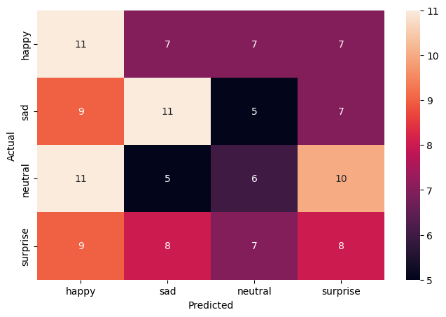

```python
from sklearn.metrics import classification_report
from sklearn.metrics import confusion_matrix

pred2_gray = model2_gray.predict(test_set_gray, steps=len(test_set_gray))
pred2_gray_labels = np.argmax(pred2_gray, axis=1)
y_true2_gray = test_set_gray.classes

# Plotting the heatmap using confusion matrix
cm2_gray = confusion_matrix(y_true2_gray, pred2_gray_labels)
plt.figure(figsize = (8, 5))
sns.heatmap(cm2_gray, annot = True,  fmt = '.0f', xticklabels = ['happy', 'sad', 'neutral', 'surprise'], yticklabels = ['happy', 'sad', 'neutral', 'surprise'])
plt.ylabel('Actual')
plt.xlabel('Predicted')
plt.show()
```

```python
report2_gray = classification_report(y_true2_gray, pred2_gray_labels)
print(report2_gray)
```

```
              precision    recall  f1-score   support

           0       0.28      0.34      0.31        32
           1       0.35      0.34      0.35        32
           2       0.24      0.19      0.21        32
           3       0.25      0.25      0.25        32

    accuracy                           0.28       128
   macro avg       0.28      0.28      0.28       128
weighted avg       0.28      0.28      0.28       128
```

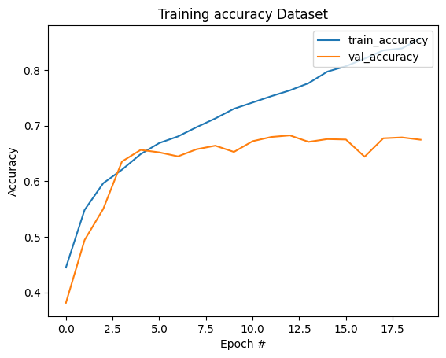

```python
def plot_history(history):
    N = len(history.history["accuracy"])
    plt.figure()
    plt.plot(np.arange(0, N), history.history["accuracy"], label="train_accuracy")
    plt.plot(np.arange(0, N), history.history["val_accuracy"], label="val_accuracy")
    plt.title("Training accuracy Dataset")
    plt.xlabel("Epoch #")
    plt.ylabel("Accuracy")
    plt.legend(loc="upper right")
plot_history(history_model2_gray)
```

```python
# Clearing backend
from tensorflow.keras import backend
backend.clear_session()

# Fixing the seed for random number generators
np.random.seed(42)
import random
random.seed(42)
tf.random.set_seed(42)
```

## **Think About It:**

- Did the models have a satisfactory performance? If not, then what are the possible reasons?
- Which Color mode showed better overall performance? What are the possible reasons? Do you think having 'rgb' color mode is needed because the images are already black and white?

## **Transfer Learning Architectures**

### **Creating our Data Loaders for Transfer Learning Architectures**

In this section, we are creating data loaders that we will use as inputs to our Neural Network. We will have to go with color_mode = 'rgb' as this is the required format for the transfer learning architectures.

```python
batch_size  = 32
img_size = 48

datagen_train = ImageDataGenerator(horizontal_flip = True,
                                    brightness_range = (0., 2.),
                                    rescale = 1./255,
                                    shear_range = 0.3)

train_set = datagen_train.flow_from_directory(folder_path + "train/",
                                              target_size = (img_size, img_size),
                                              color_mode = 'rgb',
                                              batch_size = batch_size,
                                              class_mode = 'categorical',
                                              classes = ['happy', 'sad', 'neutral', 'surprise'],
                                              shuffle = True)

datagen_validation = ImageDataGenerator(rescale = 1./255)

validation_set = datagen_train.flow_from_directory(folder_path + "validation/",
                                              target_size = (img_size, img_size),
                                              color_mode = 'rgb',
                                              batch_size = batch_size,
                                              class_mode = 'categorical',
                                              classes = ['happy', 'sad', 'neutral', 'surprise'],
                                              shuffle = True)

datagen_test = ImageDataGenerator(rescale = 1./255)

test_set = datagen_train.flow_from_directory(folder_path + "test/",
                                              target_size = (img_size, img_size),
                                              color_mode = 'rgb',
                                              batch_size = batch_size,
                                              class_mode = 'categorical',
                                              classes = ['happy', 'sad', 'neutral', 'surprise'],
                                              shuffle = True)
```

```
Found 15109 images belonging to 4 classes.
Found 4977 images belonging to 4 classes.
Found 128 images belonging to 4 classes.
```

## **VGG16 Model**

### **Importing the VGG16 Architecture**

```python
from tensorflow.keras.applications.vgg16 import VGG16
from tensorflow.keras import Model

vgg = VGG16(include_top = False, weights = 'imagenet', input_shape = (48, 48, 3))
vgg.summary()
```

```
Downloading data from https://storage.googleapis.com/tensorflow/keras-applications/vgg16/vgg16_weights_tf_dim_ordering_tf_kernels_notop.h5
Model: "vgg16"
_________________________________________________________________
 Layer (type)                Output Shape              Param #
=================================================================
 input_1 (InputLayer)        [(None, 48, 48, 3)]       0

 block1_conv1 (Conv2D)       (None, 48, 48, 64)        1792

 block1_conv2 (Conv2D)       (None, 48, 48, 64)        36928

 block1_pool (MaxPooling2D)  (None, 24, 24, 64)        0

 block2_conv1 (Conv2D)       (None, 24, 24, 128)       73856

 block2_conv2 (Conv2D)       (None, 24, 24, 128)       147584

 block2_pool (MaxPooling2D)  (None, 12, 12, 128)       0

 block3_conv1 (Conv2D)       (None, 12, 12, 256)       295168

 block3_conv2 (Conv2D)       (None, 12, 12, 256)       590080

 block3_conv3 (Conv2D)       (None, 12, 12, 256)       590080

 block3_pool (MaxPooling2D)  (None, 6, 6, 256)         0

 block4_conv1 (Conv2D)       (None, 6, 6, 512)         1180160

 block4_conv2 (Conv2D)       (None, 6, 6, 512)         2359808

 block4_conv3 (Conv2D)       (None, 6, 6, 512)         2359808

 block4_pool (MaxPooling2D)  (None, 3, 3, 512)         0

 block5_conv1 (Conv2D)       (None, 3, 3, 512)         2359808

 block5_conv2 (Conv2D)       (None, 3, 3, 512)         2359808

 block5_conv3 (Conv2D)       (None, 3, 3, 512)         2359808

 block5_pool (MaxPooling2D)  (None, 1, 1, 512)         0

=================================================================
Total params: 14714688 (56.13 MB)
Trainable params: 14714688 (56.13 MB)
Non-trainable params: 0 (0.00 Byte)
_________________________________________________________________
```

### **Model Building**

- In this model, we will import till the **'block5_pool'** layer of the VGG16 model. You can scroll down in the model summary and look for 'block5_pool'. You can choose any other layer as well.
- Then we will add a Flatten layer, which receives the output of the 'block5_pool' layer as its input.
- We will add a few Dense layers and use 'relu' activation function on them.
- You may use Dropout and BatchNormalization layers as well.
- Then we will add our last dense layer, which must have 4 neurons and a 'softmax' activation function.

```python
transfer_layer = vgg.get_layer('block5_pool')
vgg.trainable = False

# Add classification layers on top of it

x = Conv2D(filters = 64, kernel_size = 2, padding = "same", input_shape = (48, 48, 3), activation = 'relu')(transfer_layer.output)
x = Dropout(0.2)(x)

x= Conv2D(filters = 32, kernel_size = 2, padding = "same", input_shape = (48, 48, 3), activation = 'relu')(x)
x= Dropout(0.2)(x)

# Flattenning the output from the 3rd block of the VGG16 model
x = Flatten()(x)

# Adding a Dense layer with 256 neurons
x = Dense(256, activation = 'relu')(x)

# Add a Dense Layer with 128 neurons
x = Dense(128, activation = 'relu')(x)

# Add a DropOut layer with Drop out ratio of 0.3
x = Dropout(0.3)(x)

# Add a Dense Layer with 64 neurons
x = Dense(64, activation = 'relu')(x)

# Add a Batch Normalization layer
x = BatchNormalization()(x)

# Adding the final dense layer with 4 neurons and use 'softmax' activation
pred = Dense(4, activation='softmax')(x)

vggmodel = Model(vgg.input, pred) # Initializing the model
```

### **Compiling and Training the VGG16 Model**

```python
from keras.callbacks import ModelCheckpoint, EarlyStopping, ReduceLROnPlateau

checkpoint = ModelCheckpoint("./vggmodel.h5", monitor = 'val_loss', verbose = 1, save_best_only = True, mode = 'max')

early_stopping = EarlyStopping(monitor = 'val_loss',
                          min_delta = 0,
                          patience = 3,
                          verbose = 1,
                          restore_best_weights = True
                          )

reduce_learningrate = ReduceLROnPlateau(monitor = 'val_loss',
                              factor = 0.2,
                              patience = 3,
                              verbose = 1,
                              min_delta = 0.0001)

callbacks_list = [early_stopping, checkpoint, reduce_learningrate]

epochs = 20
```

```python
# Code to compile the vggmodel. Use categorical crossentropy as the loss function, Adam Optimizer with 0.001 learning rate, and set metrics to 'accuracy'.

vggmodel.compile(optimizer=tf.keras.optimizers.Adam(learning_rate=0.001),loss='categorical_crossentropy', metrics=['accuracy'])
```

```python
# Code to fit  model. Use train_set as the training data and validation_set as the validation data. Train the model for 20 epochs.
history_vgg  = vggmodel.fit(train_set, epochs=20, validation_data=validation_set, verbose=1)
```

### **Evaluating the VGG16 model**

```python
# Code to evaluate model performance on the test set
test_images, test_labels = next(test_set)
accuracy = vggmodel.evaluate(test_images, test_labels, verbose = 2)
```

```
1/1 - 0s - loss: 1.2119 - accuracy: 0.4375 - 35ms/epoch - 35ms/step
```

```
1/1 - 0s - loss: 1.2198 - accuracy: 0.4062 - 35ms/epoch - 35ms/step
```

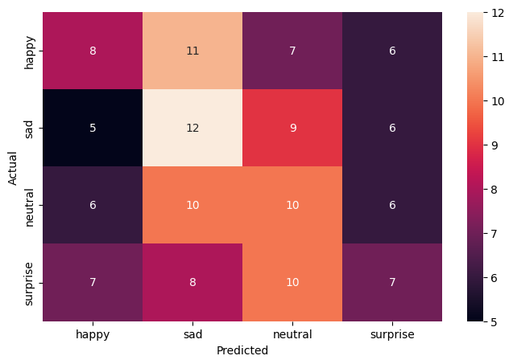

```python
# Code to evaluate model performance on the test set
test_images, test_labels = next(test_set)
accuracy = vggmodel.evaluate(test_images, test_labels, verbose = 2)

from sklearn.metrics import classification_report
from sklearn.metrics import confusion_matrix

predvgg = vggmodel.predict(test_set, steps=len(test_set))
predvgg_labels = np.argmax(predvgg, axis=1)
y_truevgg = test_set.classes

# Plotting the heatmap using confusion matrix
cmvgg = confusion_matrix(y_truevgg, predvgg_labels)
plt.figure(figsize = (8, 5))
sns.heatmap(cmvgg, annot = True,  fmt = '.0f', xticklabels = ['happy', 'sad', 'neutral', 'surprise'], yticklabels = ['happy', 'sad', 'neutral', 'surprise'])
plt.ylabel('Actual')
plt.xlabel('Predicted')
plt.show()
```

```python
reportvgg = classification_report(y_truevgg, predvgg_labels)
print(reportvgg)
```

```
              precision    recall  f1-score   support

           0       0.38      0.31      0.34        32
           1       0.30      0.41      0.35        32
           2       0.28      0.31      0.29        32
           3       0.35      0.25      0.29        32

    accuracy                           0.32       128
   macro avg       0.33      0.32      0.32       128
weighted avg       0.33      0.32      0.32       128
```

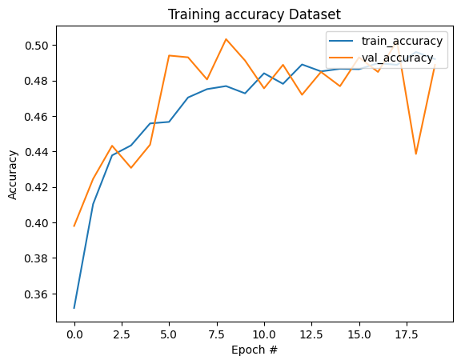

```python
def plot_history(history):
    N = len(history.history["accuracy"])
    plt.figure()
    plt.plot(np.arange(0, N), history.history["accuracy"], label="train_accuracy")
    plt.plot(np.arange(0, N), history.history["val_accuracy"], label="val_accuracy")
    plt.title("Training accuracy Dataset")
    plt.xlabel("Epoch #")
    plt.ylabel("Accuracy")
    plt.legend(loc="upper right")
plot_history(history_vgg)
```

```python
# Clearing backend
from tensorflow.keras import backend
backend.clear_session()

# Fixing the seed for random number generators
np.random.seed(42)
import random
random.seed(42)
tf.random.set_seed(42)
```

**Observations and Insights:__**

- There is some significant noise in the validation accuracy, while both accuracies being low.
- VGG doesn't seem to be working well with this dataset.

**Note: You can even go back and build own architecture on top of the VGG16 Transfer layer and see if you can improve the performance**

```python
import tensorflow as tf
import tensorflow.keras.applications as ap
from tensorflow.keras import Model

Resnet = ap.ResNet101(include_top = False, weights = "imagenet", input_shape=(48,48,3))
Resnet.summary()
```

```
Downloading data from https://storage.googleapis.com/tensorflow/keras-applications/resnet/resnet101_weights_tf_dim_ordering_tf_kernels_notop.h5
Model: "resnet101"
__________________________________________________________________________________________________
 Layer (type)                Output Shape                 Param #   Connected to
==================================================================================================
 input_1 (InputLayer)        [(None, 48, 48, 3)]          0         []

 conv1_pad (ZeroPadding2D)   (None, 54, 54, 3)            0         ['input_1[0][0]']

 conv1_conv (Conv2D)         (None, 24, 24, 64)           9472      ['conv1_pad[0][0]']

 conv1_bn (BatchNormalizati  (None, 24, 24, 64)           256       ['conv1_conv[0][0]']
 on)

 conv1_relu (Activation)     (None, 24, 24, 64)           0         ['conv1_bn[0][0]']

 pool1_pad (ZeroPadding2D)   (None, 26, 26, 64)           0         ['conv1_relu[0][0]']

 pool1_pool (MaxPooling2D)   (None, 12, 12, 64)           0         ['pool1_pad[0][0]']

 conv2_block1_1_conv (Conv2  (None, 12, 12, 64)           4160      ['pool1_pool[0][0]']
 D)

 conv2_block1_1_bn (BatchNo  (None, 12, 12, 64)           256       ['conv2_block1_1_conv[0][0]']
 rmalization)

 conv2_block1_1_relu (Activ  (None, 12, 12, 64)           0         ['conv2_block1_1_bn[0][0]']
 ation)

 conv2_block1_2_conv (Conv2  (None, 12, 12, 64)           36928     ['conv2_block1_1_relu[0][0]']
 D)

 conv2_block1_2_bn (BatchNo  (None, 12, 12, 64)           256       ['conv2_block1_2_conv[0][0]']
 rmalization)

 conv2_block1_2_relu (Activ  (None, 12, 12, 64)           0         ['conv2_block1_2_bn[0][0]']
 ation)

 conv2_block1_0_conv (Conv2  (None, 12, 12, 256)          16640     ['pool1_pool[0][0]']
 D)
```

[output cut: 984 more lines]

```

 conv5_block3_3_bn (BatchNo  (None, 2, 2, 2048)           8192      ['conv5_block3_3_conv[0][0]']
 rmalization)

 conv5_block3_add (Add)      (None, 2, 2, 2048)           0         ['conv5_block2_out[0][0]',
                                                                     'conv5_block3_3_bn[0][0]']

 conv5_block3_out (Activati  (None, 2, 2, 2048)           0         ['conv5_block3_add[0][0]']
 on)

==================================================================================================
Total params: 42658176 (162.73 MB)
Trainable params: 42552832 (162.33 MB)
Non-trainable params: 105344 (411.50 KB)
__________________________________________________________________________________________________
```

### **Model Building**

- In this model, we will import till the **'conv5_block3_add'** layer of the ResNet model.
- Then we will add a Flatten layer, which receives the output of the 'conv5_block3_add' layer as its input.
- We will add a few Dense layers and use 'relu' activation function on them.
- We will use Dropout and BatchNormalization layers as well.
- Then we will add our last dense layer, which must have 4 neurons and a 'softmax' activation function.

```python
transfer_layer_Resnet = Resnet.get_layer('conv5_block3_add')
Resnet.trainable=False

# Add classification layers on top of it
x = Conv2D(filters = 64, kernel_size = 2, padding = "same", input_shape = (48, 48, 3), activation = 'relu')(transfer_layer.output)
x = Dropout(0.2)(x)

x= Conv2D(filters = 32, kernel_size = 2, padding = "same", input_shape = (48, 48, 3), activation = 'relu')(x)
x= Dropout(0.2)(x)

x= Conv2D(filters = 16, kernel_size = 2, padding = "same", input_shape = (48, 48, 3), activation = 'relu')(x)
x= Dropout(0.2)(x)

# Flattenning the output from the 3rd block of the VGG16 model
x = Flatten()(transfer_layer_Resnet.output)

# Add a Dense layer with 256 neurons
x = Dense(256, activation = 'relu')(x)

# Add a Dense Layer with 128 neurons
x = Dense(128, activation = 'relu')(x)


# Add a DropOut layer with Drop out ratio of 0.3
x = Dropout(0.3)(x)

# Add a Dense Layer with 64 neurons
x = Dense(64, activation = 'relu')(x)

# Add a Batch Normalization layer
x = BatchNormalization()(x)

# Add the final dense layer with 4 neurons and use a 'softmax' activation
pred = Dense(4, activation = 'softmax')(x)

resnetmodel = Model(Resnet.input, pred) # Initializing the model
```

### **Compiling and Training the Model**

```python
from keras.callbacks import ModelCheckpoint, EarlyStopping, ReduceLROnPlateau

checkpoint = ModelCheckpoint("./Resnetmodel.h5", monitor = 'val_acc', verbose = 1, save_best_only = True, mode = 'max')

early_stopping = EarlyStopping(monitor = 'val_loss',
                          min_delta = 0,
                          patience = 3,
                          verbose = 1,
                          restore_best_weights = True
                          )

reduce_learningrate = ReduceLROnPlateau(monitor = 'val_loss',
                              factor = 0.2,
                              patience = 3,
                              verbose = 1,
                              min_delta = 0.0001)

callbacks_list = [early_stopping, checkpoint, reduce_learningrate]

epochs = 10
```

```python
# Code to compile  resnetmodel. Use categorical crossentropy as  loss function, Adam Optimizer with 0.001 learning rate, and set  metrics to 'accuracy'.
resnetmodel.compile(optimizer=tf.keras.optimizers.Adam(learning_rate=0.001),loss='categorical_crossentropy', metrics=['accuracy'])
```

```python
 # Code to fit  model. Use train_set as  training data and validation_set as  validation data. Train  model for 20 epochs.
history_resnet  = resnetmodel.fit(train_set, epochs=20, validation_data=validation_set, verbose=1)
```

### **Evaluating the ResNet Model**

```python
# Code to evaluate model performance on the test set
test_images, test_labels = next(test_set)
accuracy_resnet = resnetmodel.evaluate(test_images, test_labels, verbose = 2)
```

```
1/1 - 0s - loss: 1.3929 - accuracy: 0.1875 - 63ms/epoch - 63ms/step
```

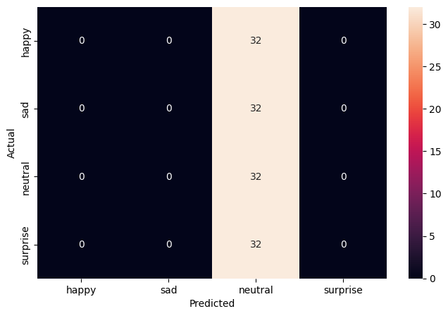

```python
pred_resnet = resnetmodel.predict(test_set, steps=len(test_set))
pred_resnet_labels = np.argmax(pred_resnet, axis=1)
y_true = test_set.classes

# Plotting the heatmap using confusion matrix
cm_resnet = confusion_matrix(y_true, pred_resnet_labels)
plt.figure(figsize = (8, 5))
sns.heatmap(cm_resnet, annot = True,  fmt = '.0f', xticklabels = ['happy', 'sad', 'neutral', 'surprise'], yticklabels = ['happy', 'sad', 'neutral', 'surprise'])
plt.ylabel('Actual')
plt.xlabel('Predicted')
plt.show()
```

```python
report_resnet = classification_report(y_true, pred_resnet_labels)
print(report_resnet)
```

```
              precision    recall  f1-score   support

           0       0.00      0.00      0.00        32
           1       0.00      0.00      0.00        32
           2       0.25      1.00      0.40        32
           3       0.00      0.00      0.00        32

    accuracy                           0.25       128
   macro avg       0.06      0.25      0.10       128
weighted avg       0.06      0.25      0.10       128
```

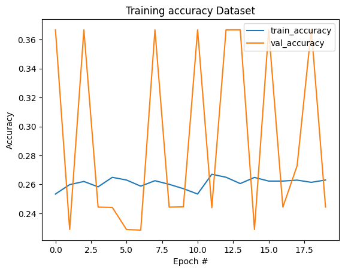

```python
plot_history(history_resnet)
```

```python
# Clearing backend
from tensorflow.keras import backend
backend.clear_session()

# Fixing the seed for random number generators
np.random.seed(42)
import random
random.seed(42)
tf.random.set_seed(42)
```

**Observations and Insights:__**

- The performance is limited due to the existing layers not being able to train

## **EfficientNet Model**

```python
import tensorflow as tf
import tensorflow.keras.applications as ap
from tensorflow.keras import Model
EfficientNet = ap.EfficientNetV2B2(include_top=False,weights="imagenet", input_shape= (48, 48, 3))

EfficientNet.summary()
```

```
Downloading data from https://storage.googleapis.com/tensorflow/keras-applications/efficientnet_v2/efficientnetv2-b2_notop.h5
Model: "efficientnetv2-b2"
__________________________________________________________________________________________________
 Layer (type)                Output Shape                 Param #   Connected to
==================================================================================================
 input_1 (InputLayer)        [(None, 48, 48, 3)]          0         []

 rescaling (Rescaling)       (None, 48, 48, 3)            0         ['input_1[0][0]']

 normalization (Normalizati  (None, 48, 48, 3)            0         ['rescaling[0][0]']
 on)

 stem_conv (Conv2D)          (None, 24, 24, 32)           864       ['normalization[0][0]']

 stem_bn (BatchNormalizatio  (None, 24, 24, 32)           128       ['stem_conv[0][0]']
 n)

 stem_activation (Activatio  (None, 24, 24, 32)           0         ['stem_bn[0][0]']
 n)

 block1a_project_conv (Conv  (None, 24, 24, 16)           4608      ['stem_activation[0][0]']
 2D)

 block1a_project_bn (BatchN  (None, 24, 24, 16)           64        ['block1a_project_conv[0][0]']
 ormalization)

 block1a_project_activation  (None, 24, 24, 16)           0         ['block1a_project_bn[0][0]']
  (Activation)

 block1b_project_conv (Conv  (None, 24, 24, 16)           2304      ['block1a_project_activation[0
 2D)                                                                ][0]']

 block1b_project_bn (BatchN  (None, 24, 24, 16)           64        ['block1b_project_conv[0][0]']
 ormalization)

 block1b_project_activation  (None, 24, 24, 16)           0         ['block1b_project_bn[0][0]']
  (Activation)

 block1b_drop (Dropout)      (None, 24, 24, 16)           0         ['block1b_project_activation[0
                                                                    ][0]']
```

[output cut: 938 more lines]

```
                                                                     'block6i_add[0][0]']

 top_conv (Conv2D)           (None, 2, 2, 1408)           292864    ['block6j_add[0][0]']

 top_bn (BatchNormalization  (None, 2, 2, 1408)           5632      ['top_conv[0][0]']
 )

 top_activation (Activation  (None, 2, 2, 1408)           0         ['top_bn[0][0]']
 )

==================================================================================================
Total params: 8769374 (33.45 MB)
Trainable params: 8687086 (33.14 MB)
Non-trainable params: 82288 (321.44 KB)
__________________________________________________________________________________________________
```

### **Model Building**

**Build Architecture on top of the transfer layer. Be sure to have a Flatten layer after transfer layer and also make sure you have 4 neurons and softmax activation function in last dense layer**

```python
transfer_layer_EfficientNet = EfficientNet.get_layer('block6e_expand_activation')
EfficientNet.trainable = False

# Add Conv2D layer with 256 filters on top of the existing transfer layer
x = Conv2D(filters = 256, kernel_size = 2, padding = "same", activation = 'relu')(transfer_layer_EfficientNet.output)
x = BatchNormalization()(x)
x = LeakyReLU(0.1)(x)
x = MaxPooling2D(pool_size = 2)(x)

# Apply the Flatten layer
x = Flatten()(x)

# Add  Dense layers and/or BatchNormalization and Dropout layers
x = Dense(1024, activation='relu')(x)
x = BatchNormalization()(x)
x = Dropout(0.5)(x)

# Add  final Dense layer with 4 neurons and softmax activation function.
x = Dense(4, activation='softmax')(x)

EfficientNetmodel = Model(EfficientNet.input, x)
EfficientNetmodel.summary()
```

```
Model: "model_3"
__________________________________________________________________________________________________
 Layer (type)                Output Shape                 Param #   Connected to
==================================================================================================
 input_1 (InputLayer)        [(None, 48, 48, 3)]          0         []

 rescaling (Rescaling)       (None, 48, 48, 3)            0         ['input_1[0][0]']

 normalization (Normalizati  (None, 48, 48, 3)            0         ['rescaling[0][0]']
 on)

 stem_conv (Conv2D)          (None, 24, 24, 32)           864       ['normalization[0][0]']

 stem_bn (BatchNormalizatio  (None, 24, 24, 32)           128       ['stem_conv[0][0]']
 n)

 stem_activation (Activatio  (None, 24, 24, 32)           0         ['stem_bn[0][0]']
 n)

 block1a_project_conv (Conv  (None, 24, 24, 16)           4608      ['stem_activation[0][0]']
 2D)

 block1a_project_bn (BatchN  (None, 24, 24, 16)           64        ['block1a_project_conv[0][0]']
 ormalization)

 block1a_project_activation  (None, 24, 24, 16)           0         ['block1a_project_bn[0][0]']
  (Activation)

 block1b_project_conv (Conv  (None, 24, 24, 16)           2304      ['block1a_project_activation[0
 2D)                                                                ][0]']

 block1b_project_bn (BatchN  (None, 24, 24, 16)           64        ['block1b_project_conv[0][0]']
 ormalization)

 block1b_project_activation  (None, 24, 24, 16)           0         ['block1b_project_bn[0][0]']
  (Activation)

 block1b_drop (Dropout)      (None, 24, 24, 16)           0         ['block1b_project_activation[0
                                                                    ][0]']

```

[output cut: 710 more lines]

```
 dense_10 (Dense)            (None, 1024)                 263168    ['flatten_6[0][0]']

 batch_normalization_20 (Ba  (None, 1024)                 4096      ['dense_10[0][0]']
 tchNormalization)

 dropout_4 (Dropout)         (None, 1024)                 0         ['batch_normalization_20[0][0]
                                                                    ']

 dense_11 (Dense)            (None, 4)                    4100      ['dropout_4[0][0]']

==================================================================================================
Total params: 6252202 (23.85 MB)
Trainable params: 1548036 (5.91 MB)
Non-trainable params: 4704166 (17.94 MB)
__________________________________________________________________________________________________
```

### **Compiling and Training the Model**

```python
# Code to compile  Efficientnetmodel. Use categorical crossentropy as  loss function, Adam Optimizer with 0.001 learning rate, and set  metrics to 'accuracy'.
from keras.callbacks import ModelCheckpoint, EarlyStopping, ReduceLROnPlateau

checkpoint = ModelCheckpoint("./Efficientnetmodel.h5", monitor='val_acc', verbose=1, save_best_only=True, mode='max')

early_stopping = EarlyStopping(monitor = 'val_loss',
                          min_delta = 0,
                          patience = 3,
                          verbose = 1,
                          restore_best_weights = True
                          )

reduce_learningrate = ReduceLROnPlateau(monitor = 'val_loss',
                              factor = 0.2,
                              patience = 3,
                              verbose = 1,
                              min_delta = 0.0001)

callbacks_list = [early_stopping,checkpoint,reduce_learningrate]

epochs = 10
```

```python
# Code to compile  Efficientnetmodel. Use categorical crossentropy as  loss function, Adam Optimizer with 0.001 learning rate, and set  metrics to 'accuracy'.
EfficientNetmodel.compile(optimizer=tf.keras.optimizers.Adam(learning_rate=0.001),loss='categorical_crossentropy', metrics=['accuracy'])
```

### **Evaluating the EfficientnetNet Model**

```python
# Code to fit  model. Use train_set as  training data and validation_set as  validation data. Train  model for 20 epochs.
history_EfficientNet  = EfficientNetmodel.fit(train_set, epochs=20, validation_data=validation_set, verbose=1)
```

```python
# Code to evaluate the model performance on the test set
test_images, test_labels = next(test_set)
accuracy = EfficientNetmodel.evaluate(test_images, test_labels, verbose = 2)
```

```
1/1 - 0s - loss: 1.3145 - accuracy: 0.4062 - 37ms/epoch - 37ms/step
```

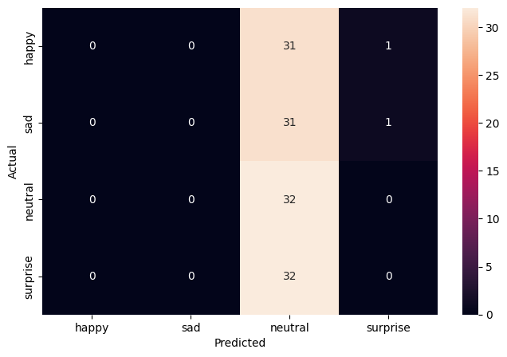

```python
predEfficientNet = EfficientNetmodel.predict(test_set, steps=len(test_set))
predEfficientNet_labels = np.argmax(predEfficientNet, axis=1)
y_true = test_set.classes

# Plotting the heatmap using confusion matrix
cmEfficientNet = confusion_matrix(y_true, predEfficientNet_labels)
plt.figure(figsize = (8, 5))
sns.heatmap(cmEfficientNet, annot = True,  fmt = '.0f', xticklabels = ['happy', 'sad', 'neutral', 'surprise'], yticklabels = ['happy', 'sad', 'neutral', 'surprise'])
plt.ylabel('Actual')
plt.xlabel('Predicted')
plt.show()
```

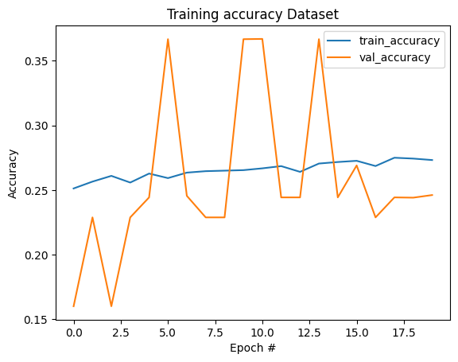

```python
plot_history(history_EfficientNet)
```

```python
report_EfficientNet = classification_report(y_true, predEfficientNet_labels)
print(report_EfficientNet)
```

```
              precision    recall  f1-score   support

           0       0.00      0.00      0.00        32
           1       0.00      0.00      0.00        32
           2       0.25      1.00      0.41        32
           3       0.00      0.00      0.00        32

    accuracy                           0.25       128
   macro avg       0.06      0.25      0.10       128
weighted avg       0.06      0.25      0.10       128
```

Now that we have tried multiple pre-trained models, let's build a complex CNN architecture and see if we can get better performance.